# Planes, Price, and Perplexity

A statistical modeling report of the price of airplane routes in India

Ryan Scibetta and Gia Ahn

March 2022

## Overview

### Introduction

There are few things in this world that are universally despised. City traffic. Wet socks. Global pandemics. And the subject of this memorandum, connecting flights at airports.

When I was a child, I often had to take connecting flights on my way to see family for the holidays (a very lucky problem to have!). My parents explained that doing so was necessary, that taking connecting flights saved money we needed to go on vacation in the first place. But I never understood how it could be less expensive to travel a longer distance than a nonstop, direct flight would take. My parents had lied to before (looking at you, Santa), so I was suspicious.

In this project, we plan to answer that childhood mystery by finding out what factors actually affect the price of a flight. Are connecting flights cheaper? Do we really save money by taking flights with multiple stops? Or is this theory full of hot air?

### The Variables

In our journey through Kaggle, we discovered a mysterious man by the name of Shray Garg. Mr. Garg is a data analyst at Infosys and a “Kaggle Expert”, as he reports in his LinkedIn. The dataset he constructed lends credence to that claim, as it contains records for over 13,000 flight routes conducted in March-June 2019. Of those flights, 10,683 of them contain both their price and the number of stops on the way to the destination.

This dataset can be found here: https://www.kaggle.com/zwartfreak/airline-fare-prediction

- Airline
- Date_of_Journey
- Source (city)
- Destination (city)
- Route (airport chain)
- Departure Time
- Arrival Time
- Duration
- Total number of stops
- Additional info (in flight meals, baggage, etc)
- Price

After data tidying, we reduce this total to the following nine variables:

1. Airline : The name of the airline brand that sponsors our flight route. There are 12 unique airlines are in this dataset: Air Asia, Air India, GoAir, IndiGo, Jet Airways, Jet Airways Business, Multiple carriers, Multiple carriers Premium Economy, SpiceJet, Trujet, Vistara, and Vistara Premium Economy.
2. Source (City of Origin) : The city that our flight route initially departs from. There are 5 cities of origin: Banglore, Chennai, Delhi, Kolkata, and Mumbai.
3. Destination (City of Destination) : The city that our flight route finally arrive to. There are 6 cities in Destination: Banglore, Cochin, Delhi, Hyderabad, Kolkata, and New Delhi.
4. DateID : A categorical conversion of the day of the year 2019 that the flight route departed, with Jan 1 having the DateID value 01 and December 31 having the DateID value 365. This dataset contains the information of flights from March 2019 through June 2019. Our dataset ranged from our first flight, DateID 60 (March 1st), to our last flight, DateID 178 (June 27th). This variable is not used in our models.
5. Weekday: The day of week that the flight departed. This is a categorical variable with seven possible values: Friday, Monday, Saturday, Sunday, Thursday, Tuesday, and Wednesday.
6. Holiday: Whether or not the flight took place within 2 days of a national holiday. (There are 3 observed national holidays in India between March and June).
7. FlightWindow: The window in which the flight departed. There are four - Morning (4am to 10am), Midday (10am to 4pm), Evening (4pm to 10pm), Overnight(10pm to 4am)
8. TotalStops: The total number of stops on flight. 0 indicates a direct flight, while a positive integer indicates layovers. The maximum value in our dataset is 4.
9. FlightTime: The total amount of time our flight route spends, beginning when it departs from its source and ending when it arrives at its destination. Recorded in minutes.
10. Price: The total cost of admission for our flight route. Recorded in Rupees.

The two variables most relevant for our purposes are the predictor variable ‘Total number of stops’ and the response variable ‘Price’. All other variables are control variables, which we will do our best to minimize. Obviously, a longer flight on Christmas Eve is going to be more expensive than a short flight in mid-March, regardless of the number of stops. Our model will adjust for these discrepancies using linear regression.

Note that throughout this report, we use versions of a variable name (ie ‘FlightTime’ vs ‘Flight Time’) interchangably. The ‘official’ names, the ones used in our code, are those outlined in the list above.

### Variable Transformations

You will notice that the variables DateID, Weekday, Holiday, FlightWindow, and FlightTime are not native to our original dataset. These five variables arise as transformations of our original columns.

DateID and Weekday originate from Date_Of_Journey and a 2019 calendar.

Holiday originates from DateID and a list of 2019 Indian holidays.

FlightWindow originates from DepartureTime.

FlightTime originates from Duration.

### Dataset Cleanings

Our initial dataset as delivered by Mr. Garg is tidy, but it needed numerous cleanings and transformations to be converted into a format usable for our purposes.

Earlier, we referenced how there were 13354 total observations in our overall dataset, but only 10,683 usable observations. This is because our default dataset is already split into a 10,683-row ‘Training’ set and a 2,671-row ‘Test’ dataset. However, the test dataset does not contain values for price. Unfortunately, as we are attempting to predict price, this makes those observations unusable for our purposes. We declined to download the ‘test’ dataset, along with its 10 columns (duplicates of our training dataset’s 11 columns sans price).

We were forced to remove the ‘Additional Info’ column from our dataset. Unfortunately, not every airline logs its additional features, like in flight meals and baggage. The airlines who do log their info have no set standard as to what each term means. Does ‘baggage’ refer to free checked bags? Free carry-ons? Extra space to place bags underneath seats? We don’t know, and so we cannot safely use the column as a predictor.

We were able to determine that the Additional Info column was not filled out by every flight by looking at the ‘red-eye’ descriptor. For some flights, this descriptor did not show up, despite the flight taking place during the ‘Overnight’ period in FlightWindow. For other flights, it did. This discrepency further cemented our lack of faith in Additional Info providing clarity.

We had some data reading issues when it came to flights of less than one hour. Our model assumes that FlightTime is formatted as *x*h *y*m (X hours and Y minutes), but when x = 0, our default dataset only outputs the minutes. There was one flight that took only five minutes to complete, which caused our dataset to mistakenly print out that it took 0 minutes, a physical impossibility. This flight was changed manually to its correct value of 5 minutes. Interestingly, there were no other flights of a duration less than an hour long. We hypothesize that each airport is at least one hour away from the others, and that the five minute flight departed and arrived that the same airport.

### Limitations

Our dataset has a limited scope. It only involves flights that took place within India, which could have a different economic model than North American brands. Our data is limited to a handful of brands and airports, limiting its scope further. The data collected is from 2019, before the coronavirus pandemic rattled the global economy.

## Tidying the Data

### Import Dataset

We start by importing Mr. Garg’s dataset into our workspace.

```r
# Read in the data
planes <- read.csv("planes.csv")
# head(planes)
```

### Data Conversion

Here, we split the column ‘Duration’ from its original format of Xh Ym into two columns; an hour column and a minute column. This is important so that we can convert the hours and minutes to a single measure of time FlightTime later. For example, 4h 15m would become 255m after our process is complete. The new column is christened ‘FlightTime’.

```r
# We need to split the column 'Duration' so that we can convert it to time
planes2 <- as_tibble(str_split_fixed(planes$Duration, 'h', n=2))

# Label the columnnames
colnames(planes2) <- c("Hours", "Min")

# removing the 'm' in Hours column
planes2$Min <- gsub("m", "", as.character(planes2$Min))

# Now coercing to numeric columns
planes2$Hours <- as.numeric(planes2$Hours)
planes2$Min <- as.numeric(planes2$Min)

# Changing NA's to Zero
planes2[is.na(planes2)] <- 0

# Creating a new vector in original planes df that totals the time in minutes
planes$FlightTime <- planes2$Hours*60+planes2$Min

#head(planes)

planes$FlightTime[planes$FlightTime == 0] <- 5

# bandaid for a strange one that got split badly since the flight time was only 5 min
planes%>%
  filter(FlightTime==0)
```

```
 [1] Airline         Date_of_Journey Source          Destination
 [5] Route           Dep_Time        Arrival_Time    Duration
 [9] Total_Stops     Additional.Info Price           X
[13] X.1             FlightTime
<0 rows> (or 0-length row.names)
```

We now need to split the column ‘Total_Stops’ into a new numeric vector. This converts our data from strings like ‘non-stop’, ‘1 stop’ ‘2 stops’, etc, into integers like ‘0’, ‘1’, ‘2’, etc. This helps our later models understand that the number of stops exists quantitatively. Plus, it looks nicer!

```r
# We need to split the column 'Total_Stops' so that we can have a separate column for numeric values
planes2 <- as_tibble(str_split_fixed(planes$Total_Stops, ' ', n=2))

# drop unnecessary column V2
planes2 <- subset(planes2, select = -V2)

# Convert to numeric
planes2$V1 <- as.numeric(planes2$V1)

# Changing NA's to Zero
planes2[is.na(planes2)] <- 0

# Adding to original DF
planes$TotalStops <- planes2$V1
#head(planes)
```

We now move on to tidying our Departure Time column, current name Dep_Times and later name FlightWindow. We go through the same process as with Duration / FlightTime in regards to splitting up the hour and minute values, but here, we use the hour column to create a new categorical variable.

We decided to group our departure times into four groups, to reduce our number of parameters and thus reduce variance in our model. Those four groups are Overnight (10 PM to 4 AM), Morning (4 AM to 10 AM), Midday (10 AM to 4 PM), and Evening (4 PM to 10 PM). The minute column is irrelevant, as our bins are arranged at the top of the hour. A flight at the top of the hour counts for the later time period: for example, a flight departing at 10 AM counts as ‘Midday’.

Note that all time-of-day measurements are taken according to IST, India Standard Time. Thankfully, it does not recognize daylight savings time, making our job easier.

```r
# We now want to clean the Dep_Time column, first we split so we can isolate the hr and minutes
planes2 <- as_tibble(str_split_fixed(planes$Dep_Time, ':', n=2))
colnames(planes2) <- c('Hour', 'Min')

# We can look categorize times into (EarlyMorning, Midday, Evening, Late) or we can leave it like this for a second.

#head(planes2)

# Lets create factor levels based on time of day. We categorize between 4am - 10 am as Morning, 10am-4pm as midday, 4pm -10 pm as evening, 10pm to 4am as overnight.

# initializing a column using the character column Hour fir a FLIGHT WINDOW column
planes2$window <-planes2$Hour

# Now we convert the column Hour to index our conditional statements. (Not converting will evaluate character value not NUMERIC)
planes2$Hour <- as.numeric(planes2$Hour)

# Might as well convert the min column too although we probably dont need either in the final dataset. Will delete as we go
planes2$Min <- as.numeric(planes2$Min)


# For loop to fill our initialized window column.
for(i in 1:nrow(planes2)) {
  if (planes2[i,1] >= 4 & planes2[i,1] < 10){
    planes2[i,3] = "Morning"
  }else if (planes2[i,1] >= 10 & planes2[i,1] < 16){
    planes2[i,3] = "Midday"
  }else if (planes2[i,1] >= 16 & planes2[i,1] < 22){
    planes2[i,3] = "Evening"
  }else if (planes2[i,1] >= 22 | planes2[i,1] < 4){
    planes2[i,3] = "Overnight"
  }
}

#head(planes2)

#Ok lets add this to our planes dataframe as a factor

planes$FlightWindow <- as.factor(planes2$window)

#head(planes)
```

We take a careful look into the different possibilities that the flight routes present, which you can see in the attached code chunk. Ultimately, we decide to remove Route from our dataset due to its high correlation with the origin and destination cities, labeled Source and Destination in our final dataset. The massive number of possible parameters Route presents is also a factor in our decision, as it runs a massive risk of overfitting, and it prevents our model from extrapolating to non-Indian air travel as effectively.

```r
# 12 unique routes
# unique(planes$Route)
numroutes <- as.list(unique(planes$Route))
# length(numroutes)

# 5 Unique Origininating Cities
# unique(planes$Source)
numsource <-as.list(unique(planes$Source))
# length(numsource)

# 6 Unique Destination Cities
# unique(planes$Destination)
numdest <- as.list(unique(planes$Destination))
# length(numdest)

# 12 unique Airlines
# unique(planes$Airline)
numairline <- as.list(unique(planes$Airline))
# length(numairline)
```

We clean the date column by splitting it into Months, Days, and Years. we can ignore the Years column, as every single flight in our dataset took place in the year 2019. We then combine Months and Days into a single column that describes the number of days that have passed in 2019, where January 1st is 1, January 2nd is 2, etc. This number becomes our DateID column.

DateID is not used in our model, but it is used to create two columns that will be used in our model: Holiday and Weekday.

```r
# We now want to clean the date column, first we split so we can isolate the Months Days Years
planes3 <- as_tibble(str_split_fixed(planes$Date_of_Journey, '/', n=3))
colnames(planes3) <- c('Day', 'Month', 'Year')

planes3$Day <- as.numeric(planes3$Day)
planes3$Month <- as.numeric(planes3$Month)
planes3$Year <- as.numeric(planes3$Year)
planes3$numdate <- planes3$Day

for(i in 1:nrow(planes3)) {
  if (planes3[i,2] == 03){
    planes3[i,4] = planes3[i,4] + 31 + 28
  }else if (planes3[i,2] == 04){
    planes3[i,4] = planes3[i,4] + 31 + 28 + 31
  }else if (planes3[i,2] == 05){
    planes3[i,4] = planes3[i,4] + 31 + 28 + 31 + 30
  }else if (planes3[i,2] == 06){
    planes3[i,4] = planes3[i,4] + 31 + 28 + 31 + 30 + 31
  }
}

# How many years are we covering anyway
# unique(planes3$Year) # Just 2019 then ok

# How many months are we covering
# unique(planes3$Month) # This is just covering from march through june
```

```r
# There are 2 national holidays between march and June in india in 2019
# April 14 (which is denoted as 104 in numdate)
# April 19 (which is denoted as 109)
# June 4-5 (denoted 155-156)
# holiday travel often occurs 1-2 days prior, so we reserve 102-106, 107-111 as holiday, and 151-158)

planes3$Holiday <- as.factor((planes3$numdate >= 102) & (planes3$numdate<=111) | (planes3$numdate >= 151 & (planes3$numdate <= 158)))

# unique(planes3$Holiday)

# planes3%>%
#  filter(numdate == 102:111)

#Append the numdate column to our planes data (NOTE THAT THIS IS ADDED AS NUMERIC FOR NOW BUT SHOULD NOT BE A QUANTITATIVE VAR LATER!!!!)

planes$DateID = planes3$numdate
planes$Holiday = planes3$Holiday

# head(planes)
```

Here, we use the same process to create ‘Weekday’, which tracks what day of the week it is when a plane departs on its flight route.

```r
# we see that March 1 is a friday, and has a numdate of 60. We will use the mod % function. to calculate.

# 60 %% 7 # We get 4. So any numdate that is divided by 7 with a remainder of 4 will also be a friday.

# This means that a remainder of 5 will be saturday, 6 will be sunday, 0 will be monday, 1 will be tuesday, 2 will be wednesday and 3 will be thursday.

# Let's get after it.

planes3$remainders <- planes3$numdate %% 7

# head(planes3)

# we initialize a character column. Probably a better way to do this in tidyverse but here it just makes it easier to write a function to fill the rows.
planes3$weekday <- as.character(planes3$remainders)

# now we use a for loop with conditional statements to fill our column

for(i in 1:nrow(planes3)) {
  if (planes3[i,6] == 0){
    planes3[i,7] = "Monday"
  }else if (planes3[i,6] == 1){
    planes3[i,7] = "Tuesday"
  }else if (planes3[i,6] == 2){
    planes3[i,7] = "Wednesday"
  }else if (planes3[i,6] == 3){
    planes3[i,7] = "Thursday"
  }else if (planes3[i,6] == 4){
    planes3[i,7] = "Friday"
  }else if (planes3[i,6] == 5){
    planes3[i,7] = "Saturday"
  }else if (planes3[i,6] == 6){
    planes3[i,7] = "Sunday"
  }
}

# head(planes3)

# we can add this to our planes df as a factor.

planes$Weekday <- as.factor(planes3$weekday)

# head(planes)
```

Here, we coerce Airline (brand) into a factor.

```r
planes$Airline <- as.factor(planes$Airline)

#Look at the factors
# levels(planes$Airline)

#check data

# head(planes)
```

Here, we coerce the Source and Destination columns to factors. Since the numdate is actually just an index of the date, we will convert to character.

```r
# Coerce to factor the source and destination
planes$Source <- as.factor(planes$Source)
planes$Destination<- as.factor(planes$Destination)

#head(planes)
```

### Column Cleaning

Here, we clear out our unused columns. We remove the following columns for the following reasons:

- Route: Decided not to use earlier
- X: Empty column created during other transformations
- X1: Empty column created during other transformations
- Total_Stops: created a numeric version, currently deleting the string version
- Duration: converted to FlightTime

```r
planes = subset(planes, select = -c(Route, X, X.1, Total_Stops, Duration))

#head(planes)
```

We now examine the Additional Info column, and discover its uselessness, as discussed in Dataset Cleanings.

```r
# What is in this column?
# unique(planes$Additional.Info)
#numaddinfo <- as.list(unique(planes$Additional.Info))
# length(numaddinfo)

#We see that there are some potential things that could also affect price, such as business class, and meals. We will tidy this column as a factor since there are 9 factors.

# First i'm going to combine the "No info" and "No Info" into just one capitalization.
#planes %>%
#  filter(Additional.Info == "No Info") %>%
#  mutate(Additional.Info = "No info")

# Maybe we need to pivot these columns Lets start with Buisness Class and red eye.

#planes %>%
#  filter(Additional.Info == "Business class")  # Only 4 flights are designated as business class. Hmm.

#planes %>%
#  filter(Additional.Info == "Red-eye flight")  # Only 1 flight is classified as red eye, but this isn't the only overnight flight.

#planes %>%
#  filter(FlightTime == "Overnight" & DateID == 0) # We clearly see that there are comparable flights that are overnight and they are not designated as red eye.

# This Additional information column seems to be unreliable. So we see how many of our data points have no information.
#planes %>%
#  filter(Additional.Info == "No info") # 8345, which is about 80 percent. Why don't we drop this column, as it is not reliable.
```

Here, we clear out more unused columns. We remove the following columns for the following reasons:

- Additional Info: provides no useful additional info
- Dep_Time: accounted for in Flight_Window
- Arrival Time: not used due to Flight_Window. We made a judgement call that departure time affects the supply/demand rates of flights more than arrival time.
- Date_Of_Journey, replaced by DateID
- DateID, served its purpose by creating Weekday and Holiday, and can now be discarded

```r
planes = subset(planes, select = -c(Additional.Info, Dep_Time, Arrival_Time, Date_of_Journey, DateID))

#head(planes)
```

### Finalize Dataset

Here, we alter the column order into a more intuitive formate, rewrite the data frame planes, and turn Holiday’s binary from “TRUE” and “FALSE” into a prettier “Yes” and “No”.

```r
# Create a list with the order of columns
col_order <- c("Airline", "Source", "Destination", "Weekday", "Holiday", "FlightWindow", "TotalStops", "FlightTime", "Price")

# Rewrite data frame planes
planes <- planes[,col_order]

# make the holiday column prettier
levels(planes$Holiday) <- c("No", "Yes")

#head(planes)
```

We have reduced our variables to the nine listed in the ‘Variables’ section. Our data cleaning is complete!

## Exploratory Data Analysis

It is time for our exploratory data analysis, where we use the flashiest tool in the statician’s arsenal: *drumroll* **Visualizations!** This will allow us to confirm our dataset will function well for our models, determine what our models should be, and get cool graphics to show people who don’t want to read thousands of words to learn about airplanes.

### Pairs of Variables

First, let’s see each plane pair using the pairs.panels function:

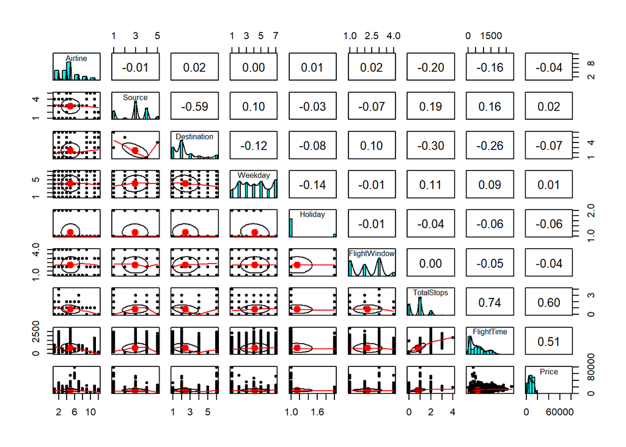

```r
# Visualizing the data

pairs.panels(planes)
```

This plane pair plot shows the interaction between each pair of variables in our dataset. On the upper-left to lower-right diagonal, there is a histogram of each variable. Below the diagonal, we see the two variables plotted against each other, with a line of best fit outlined in red. Above the diagonal, we see a real number corresponding to the Pearson correlation between the two variables.

Note that the Pearson correlation $r$ is *not* the same thing as the coefficient of determination $R^2$. The Pearson correlation is used for finding patterns, while the coefficient of determination is used for evaluating the strenth of a model. We will be seeing the coefficient of determination below, in the Modeling section of this report.

Most of our pairs of variables have weak to no correlation. However, there are a few exceptions we would like to highlight:

Our strongest corrlelation is between Total Stops and Flight Time. This also makes sense; if you have to stop at multiple airports, the total amount off time your trip will take should increase in response. This is further exacerbated by the fact that Flight Time tracks time from departure to arrival, *including* time when the plane is sitting idle at a connecting airport.

Significantly, there are strong positive correlation between Price and Total Stops (0.60). There is a similarly strong positive correlation between Price and FlightTime (0.51). This doesn’t itself show that Price increases as the number of stops increase, due to the strongly correlating factors of FlightTime, and the lack of controlling for effects such as Holiday, Weekday, Airline, etc. Still, it’s interesting to note during our pattern recognition stage.

### Histogram of Price

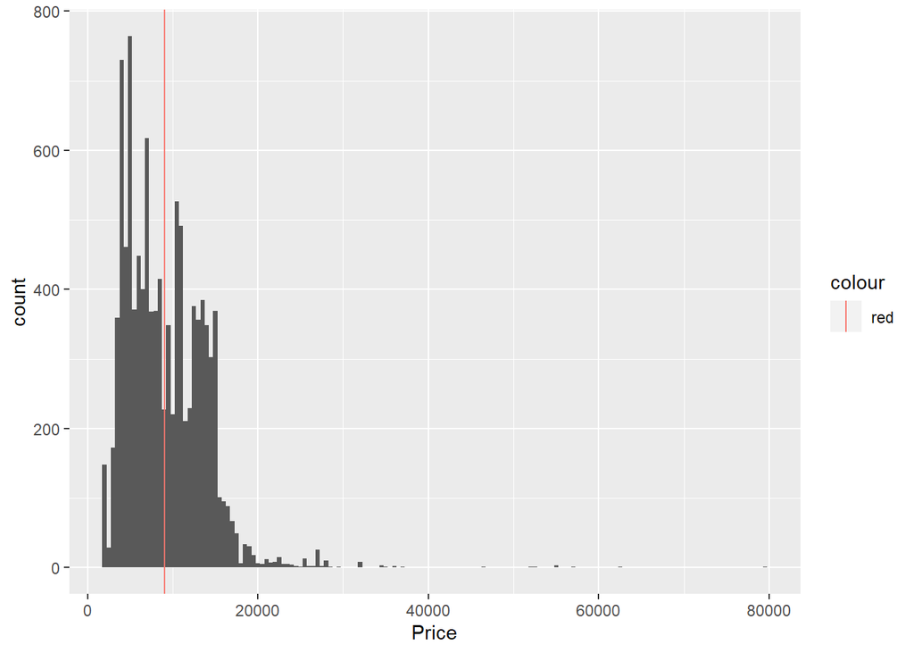

```r
# Visualizing the price in histogram
planes%>%
  ggplot(aes(x = Price))+
  geom_histogram(binwidth = 500)+
  geom_vline(aes(xintercept = mean(planes$Price), color = "red"))
```

We see that our observations of Price are right-tailed, with a mean of $9088.064$ and a median of $8373$. While most of our observations are well below 20,000 rupees, there are a handful of outliers reaching far out, in some cases over 60,000 rupees.

### Airplane Brand Exploration

Let’s now model our different brands of airplanes. Spoiler alert: this will help us discover why we have such extreme outliers!

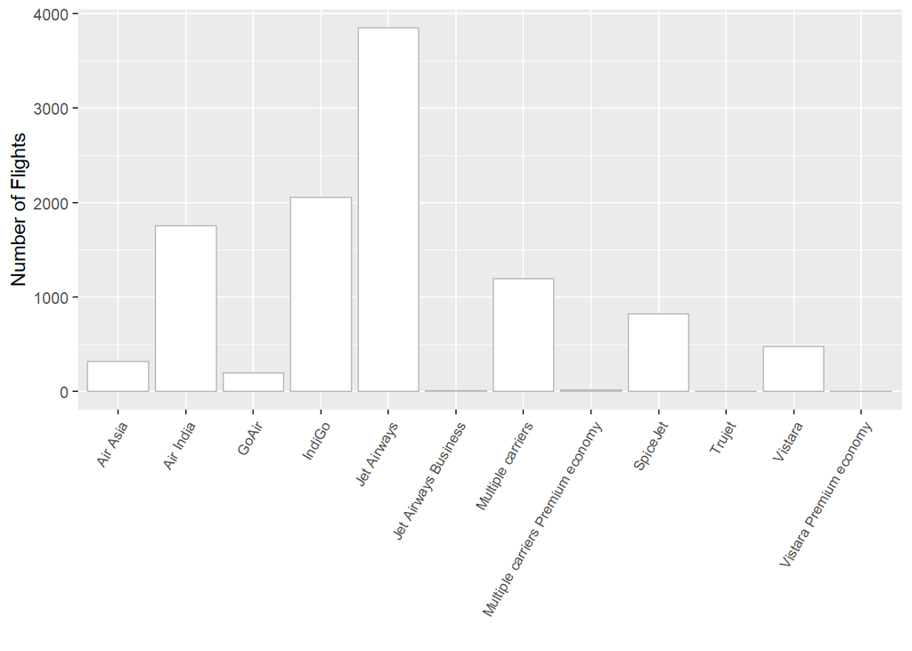

```r
# Finding the airline frequency of flights

planes%>%
  ggplot()+
  geom_histogram(aes(x = Airline), stat = "count", color = "gray", fill = "white")+
  theme(axis.text.x = element_text(size = 8, angle = 60, hjust = 1))+ # adjusts only x-axis text
  labs(main = "Number of Flights between March - June 2019", x= '', y= "Number of Flights")
```

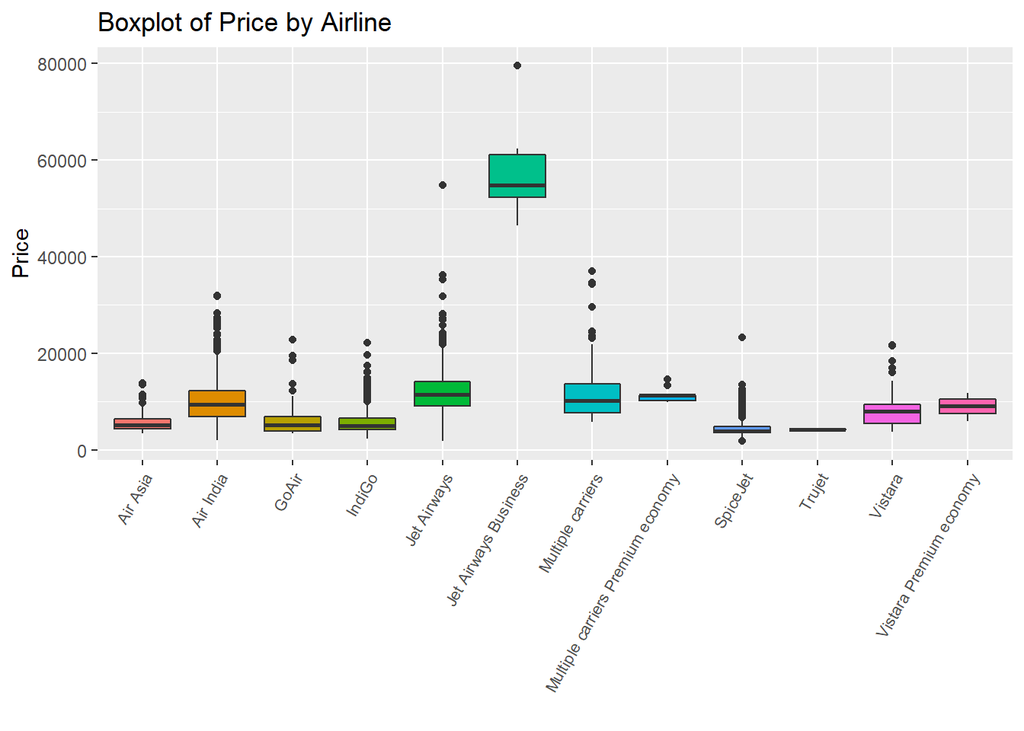

```r
# boxplots of prices per airline

ggplot(data = planes, mapping = aes(y = Price, x = Airline, fill = Airline)) +
  geom_boxplot()+
  theme(legend.position = "none", axis.text.x = element_text(size = 8, angle = 60, hjust = 1))+   # remove legend (redundant)+
  labs(title = "Boxplot of Price by Airline", x = '')
```

### Jet Airways Business

What is up with Jet Airways Business? It is so much more expensive than every other airplane brand! After some research, we discovered that Jet Airways Business is an offshoot of Jet Airways catered towards business-class flights. They’re serving a luxury market that completely differs from the rest of our airlines.

Interestingly, ‘Multiple Carriers Premium Economy’ and ‘Vistara Premium Economy’ do not have the same radical price increase. We believe that these offshoot brands offer small perks like extra legroom rather than the massive luxury boots that ‘Jet Airways Business’ offers.

Jet Airways Business’ status as a business-class-only brand means their flights are not applicable to the economic models of economy class flights. They only contribute a small handful of flights into our dataset, but those flights massively influence our visualizations, overcentralizing our dataset in its image. We must remove Jet Airways Business from our dataset.

```r
## removing Jet Airways business
planes <- planes%>%
  filter(planes$Airline != 'Jet Airways Business')

#
```

## Modeling

### Ridge Regression

#### Setup

We begin by splitting our dataset into a training and a test set for our various models. We decided to randomly sample 80% of our dataset to turn into the training set, and leave the remaining 20% as the test set. Because of our large number of observations, we are able to use a larger proportion of our observations to fuel our training set. Our test set still has over 2,000 unique observations to its own, so it will be sufficient to test our more refined, powerful models.

```r
# set seed for reproducibility
set.seed(123)

# model matrix function produces a matrix corresponding to all 33 predictors and automatically transforms any qualitative variables to dummy variables
x = model.matrix(Price ~., planes)[, -1]
y = planes$Price

# split the data by randomly selecting 80 percent as training, remainder to test
train <- sample(1:nrow(x), 0.8*nrow(x))
test <- (-train)

x.train = x[train,]
y.train = y[train]
x.test = x[test,]
y.test = y[test]
```

We then fit a basic ridge regression to use as a skeleton for later, more refined models.

```r
# fit a ridge regression model
grid = 10^seq(10, -2, length = 100)
ridge_mod = glmnet(x, y, alpha = 0, lamda = grid)
```

#### Fact-Finding Queries

We run a variety of exploratory queries to learn more about the model. They’re commented out for this report, since they don’t contribute to the building of the model itself.

```r
#ridge_mod$lambda[50] # Display 50th lambda value

#coef(ridge_mod)[,50] # Display coefficients associated with 50th lambda value

#sum(coef(ridge_mod)[-1, 50]^2) # calculate L2 norm squared

# ridge_mod$lambda[60] # Display 60th lambda value

#coef(ridge_mod)[,60] # Display coefficients associated with 60th lambda value

#sum(coef(ridge_mod)[-1, 60]^2) # calculate L2 norm squared
```

L1 and L2 are the different weights used for the lasso and ridge regression, respectively. We want to verify that as lambda value gets bigger (lambda increases), the L2 norm squared of the coefficient estimates decreases.

```r
pred <- predict(object = ridge_mod, newx  = x)
```

Next, let us fit a more complex ridge regression model on the lab-recommended lambda of $\lambda = 4$.

```r
# fit a ridge regression model on the training set and evaluate its MSE on the test set, using lambda = 4

ridge.mod=glmnet(x.train, y.train, alpha=0, lambda=grid)
ridge.pred = predict(ridge.mod, s=4, newx = x[test,])
# mean((ridge.pred-y.test)^2) # Get MSE
```

Here we try to fit a ridge regression model with a very large value of lambda, to see how our results differ from $\lambda = 4$.

```r
# Now we try to fit a ridge regression model with a very large value of lambda
ridge.pred = predict(ridge.mod, s=10^10, newx = x[test,])
# mean((ridge.pred-y.test)^2) # Get MSE of intercept only

mean((mean(y.train)-y.test)^2)# Get MSE
```

```
[1] 21941791
```

```r
# Since lambda is is large it tends to force the coefficients to be very small (close to 0) and therefore we would expect getting a model containing only an intercept. This is equivalent to fitting a constant model whose best choice is the mean of the training data. The following results indicates our conjecture is valid
```

Let’s now check how ordinary least squares regression works for our model.

```r
# Checking to see if there's any benefit of lambda = 4

ridge.pred = predict(ridge.mod, s=0, newx = x[test,])
mean((ridge.pred-y.test)^2) # Get MSE
```

```
[1] 9452480
```

Our least-squares regression method gives us a MSE of $9,452,480$. This is much lower than the $21,941,791$ of our large-lambda value, and indicates a partial-pooling style approach works best in this case.

#### Cross validation

Let us now scientifically choose the best tuning parameter instead of relying on the lab-recommended, arbitrary $\lambda = 4$.

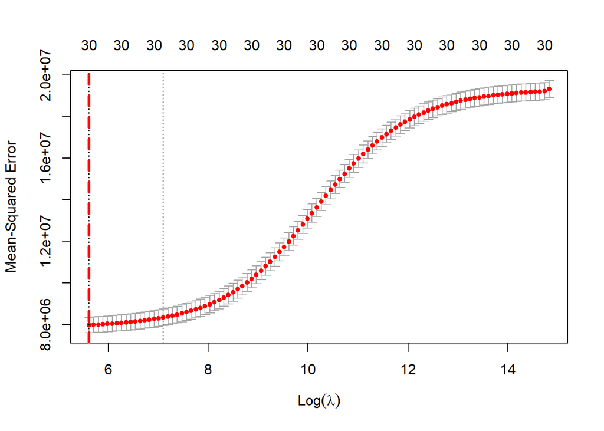

```r
set.seed(123)
cv.out.ridge = cv.glmnet(x.train, y.train, alpha = 0)
plot(cv.out.ridge)
abline(v=log(cv.out.ridge$lambda.min), col= "red", lwd = 3, lty = 2)
```

```r
#dim(x.train)
#head(x.train)
```

This graph shows us our given MSE across different values of $\log{\lambda}$. The constant $30, 30, 30, 30, 30$ at the top of the graph refers to the number of predictors in our dataset, counting our categorical variables seperately for each classification they include.

```r
# get the best lambda
bestlam = cv.out.ridge$lambda.min
bestlam
```

```
[1] 274.9703
```

We find that our best lambda value for a ridge regression is $274.9703$.

```r
ridge.pred = predict(ridge.mod, s=bestlam, newx = x[test,])
mse <- mean((ridge.pred-y.test)^2) # Get MSE
# take the square root
rmse <- sqrt(mse)
rmse
```

```
[1] 3112.912
```

A case study in our notes indicates that “OLS is ideal when the underlying relationship is Linear and we have n>>p. But if n is not much larger than p or p>n (unfeasible for OLS), there can be a lot of variability in the fit which can result in either overfitting and very poor predictive ability.”

- Source for quote: https://rstudio-pubs-static.s3.amazonaws.com/257535_4218def5fb0945a7a5c09126f385aa59.html#references

We likely have a dataset that ridge regression is not suited to solve. This is further corroborated by the contextual evidence of the strong correlations between Price and TotalStops/FlightTime that we found in our EDA.

Nevertheless, we shall proceed with our ridge regression for purposes of understanding machine learning.

#### Final Model

Below follows the best model given by the ridge regression method:

```r
# This is the best model given from the hridge regression
out = glmnet(x, y, alpha = 0)
best.pred <- predict(out, type = "coefficients", s = bestlam)[1:33,]

# best.pred

# If you would like to see the intercepts and coefficients for the ridge regression, just uncomment the 'best.pred' line above!
```

If you would like to see the intercepts and coefficients for the ridge regression, just uncomment the ‘best.pred’ line in the code chunk above!

### The Lasso (lab 5 section 3)

#### Graphics

Let us begin by creating a coefficient plot for the dataset, across different log lambda values.

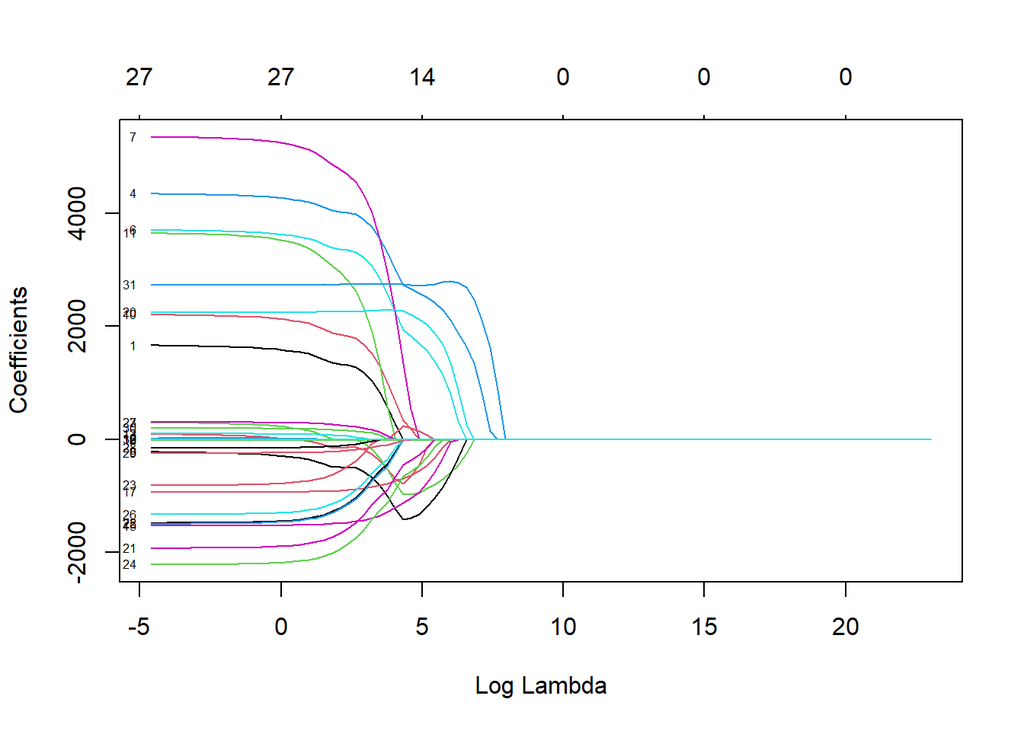

```r
lasso.mod <- glmnet(x.train, y.train, alpha=1, lambda = grid)
plot(lasso.mod, xvar = "lambda", label = TRUE)
```

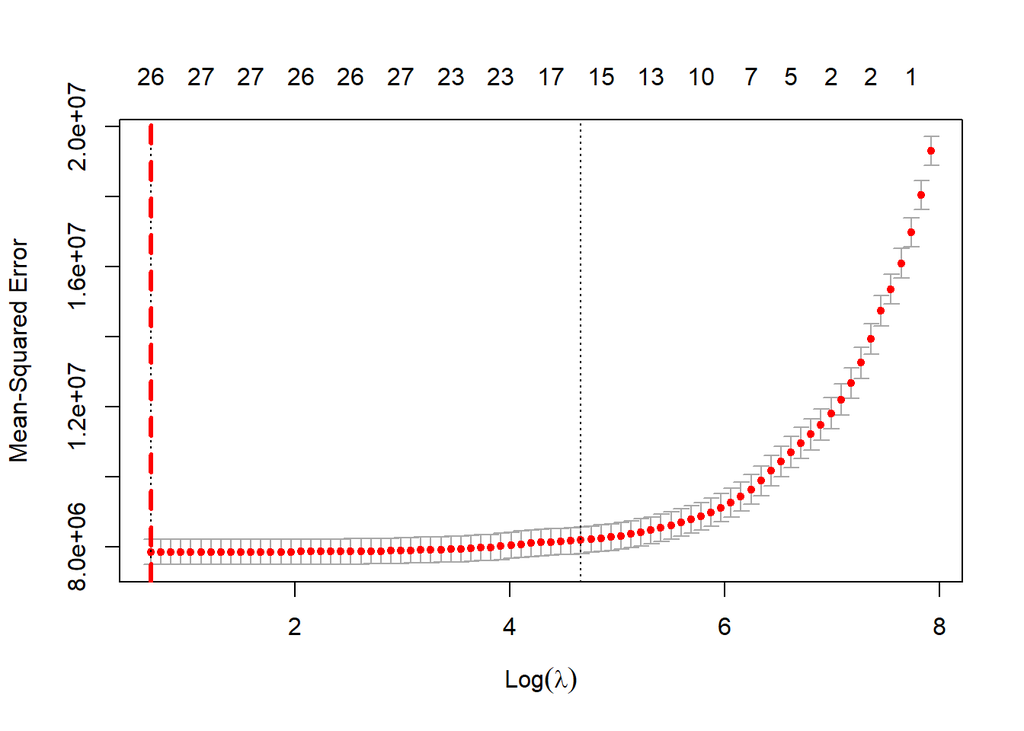

```r
# Cross validation

set.seed(123)
cv.out.lasso = cv.glmnet(x.train, y.train, alpha = 1)
plot(cv.out.lasso)
abline(v = log(cv.out.lasso$lambda.min), col = 'red', lwd=3, lty = 2)
```

Our first graphic shows us the coefficients attached to our model as affected by $\log(\lambda)$. The second shows us the mean squared error of the same model as affected by $\log(\lambda)$

Just like in Ridge regression, the numbers at the top of the graph represent the number of variables remaining in the dataset. Unlike in the Ridge regression, this number decreases as $\log{\lambda}$ increases, eventually neutralizing down to $0$. This is because, while Ridge regression lowers coefficients to negligable levels, Lasso regression lowers them all the way down to $0$, effectively making the variable affected by the coefficient cease to exist.

#### Calculations

Just like in the Ridge regression, we need to find our best lambda value computationally.

```r
bestlam = cv.out.lasso$lambda.min
bestlam
```

```
[1] 1.939861
```

It turns out that best lambda value is a small one: $1.939861$.

```r
lasso.pred = predict(lasso.mod, s = bestlam, newx = x[test,])
mse <- mean((lasso.pred-y.test)^2)
rmse <- sqrt(mse)
rmse
```

```
[1] 3075.986
```

#### Final Model

```r
out = glmnet(x, y, alpha = 1, lambda = grid)
lasso.coef = predict(out, type = "coefficients", s = bestlam)[1:33,] # I don't think its 20

# lasso.coef
```

If you would like to see the intercepts and coefficients for the lasso regression, just uncomment the ‘lasso.coef’ line in the code chunk above!

### Linear Model

#### Exploration of Linearity

Let’s recall our pairs panel:

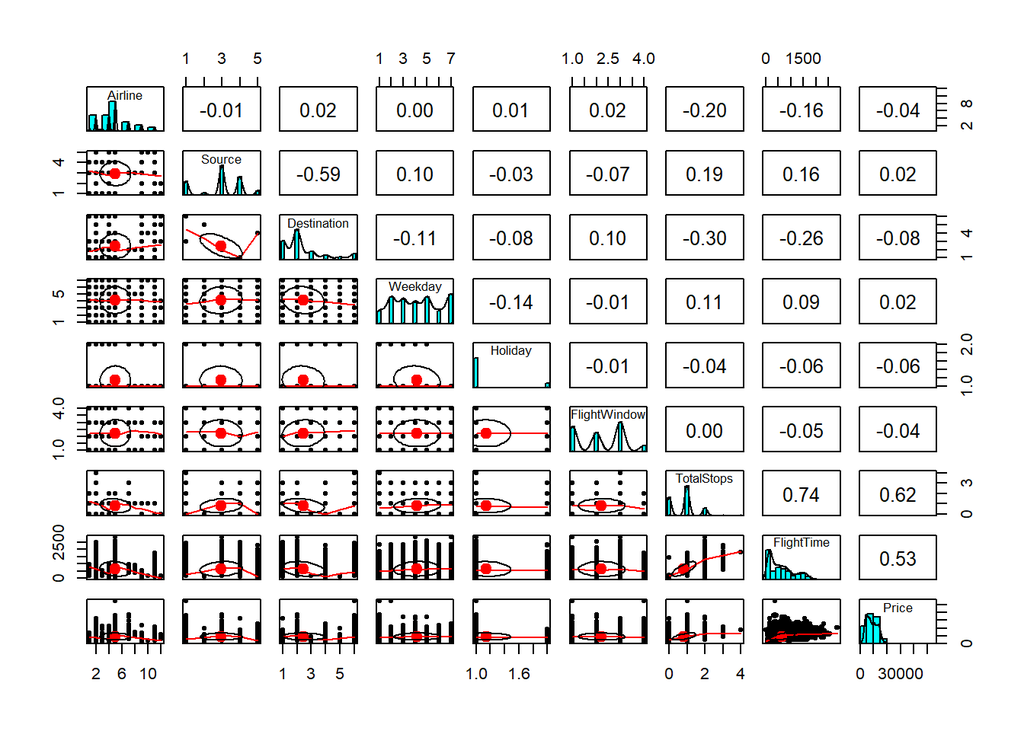

```r
pairs.panels(planes)
```

Recall that our response variable Price was heavily right skewed. To fit our linear models, we will log-transform Price, our Y variable.

```r
# Copying the planes data into a new df
planestransformed <- planes #normalized here

planestransformed$Price <- log(planestransformed$Price)
```

We saw a high correlation between total stops and flight time in our EDA, so we may encounter singularities in our model. We also see that Source and Destination is pretty highly correlated, so we can consider removing one or exploring an interaction with both. Therefore, we will fit a variety of nested models.

#### Fitting Nested Models

We will fit nine nested models: fullfit (stands for ‘fully fitted’), which uses every variable), and redmod 1-8 (stands for ‘reduced model’), eliminating strategic variables based on our dataset’s context as representing planes.

```r
# Fitting full linear model with log price since it was not normally distributed

fullfit <- lm(Price ~ Airline + Source + Destination + Weekday + Holiday + FlightWindow + TotalStops + FlightTime, data = planestransformed)

summary(fullfit)$adj.r.squared
```

```
[1] 0.717445
```

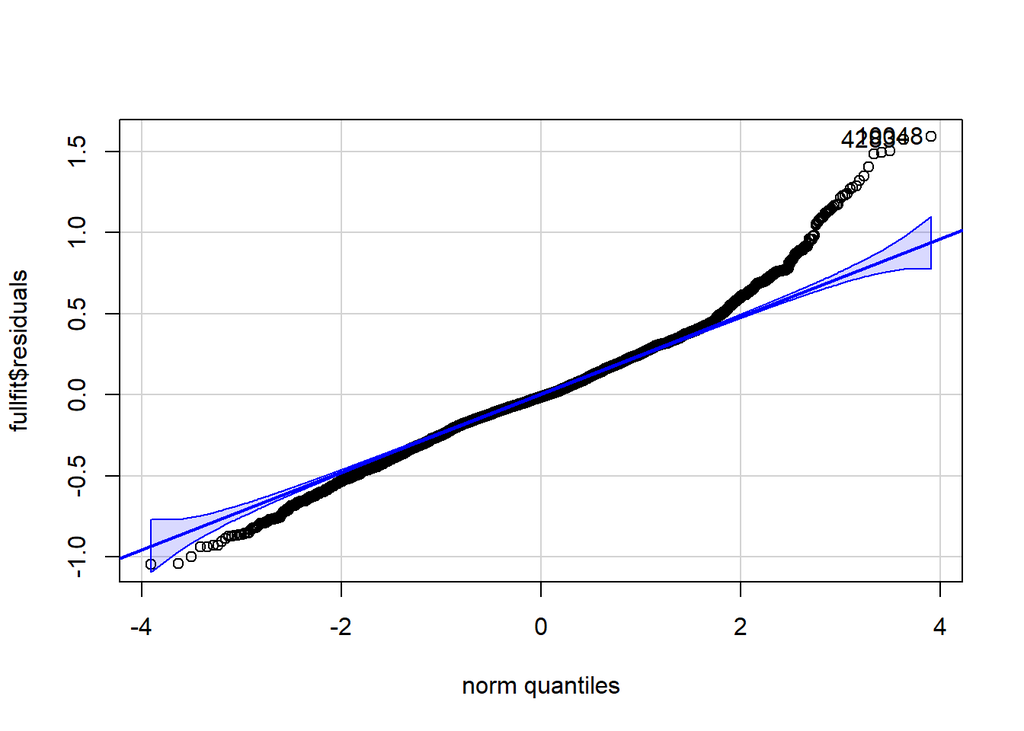

```
[1] 10048  4283
```

```r
# Plot residuals

qqPlot(fullfit$residuals)
```

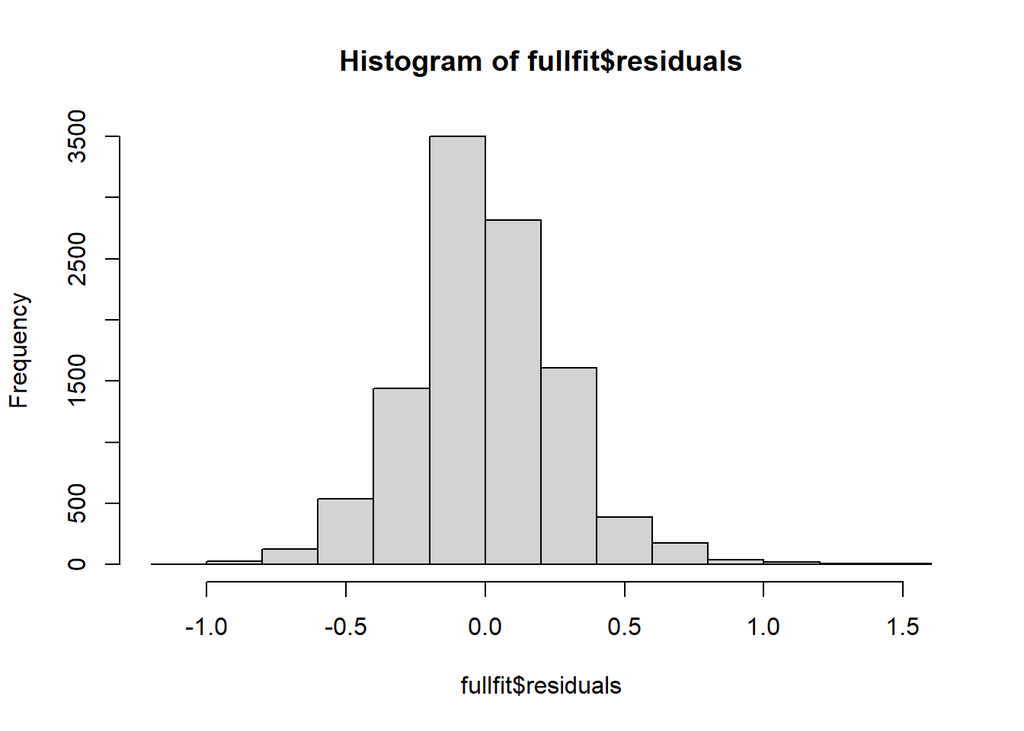

```r
#shapiro
hist(fullfit$residuals)
```

The residuals look fairly normally distributed. Because of that, we can move on to a modified backwards-stepwise method for reducing our model’s parameters. Note that our adjusted $R^2$ for the full-fit model is $0.717445$.

We want to remove either Destination or Source from our model, as they have a strong correlation identified in our EDA, and correlation can negatively affect linear models. For our first model, redmod1, let’s look at removing Source.

```r
# Fit a reduced model removing source
redmod1 <- lm(Price~Airline + Destination + Weekday + Holiday + FlightWindow + TotalStops + FlightTime, data = planestransformed)
summary(redmod1)$adj.r.squared
```

```
[1] 0.717445
```

Our adjusted R Squared, $0.717445$, didn’t change. We can compare to a model removing Destination instead:

```r
# Fit a reduced model removing Destination
redmod2 <- lm(Price~Airline + Source + Weekday + Holiday + FlightWindow + TotalStops + FlightTime, data = planestransformed)

summary(redmod2)$adj.r.squared
```

```
[1] 0.6974279
```

The adjusted Rsquared for our redmod2 model, $06974279$ is worse than in redmod1. Therefore, we choose to keep Destination over Source in our model parameters.

Our second strong correlation is between FlightTime and TotalStops. We want to remove one of the two so that we avoid the strong correlation issues. Let’s first try removing TotalStops:

```r
# Remove Stops
redmod3 <- lm(Price~Airline + Destination + Weekday + Holiday + FlightWindow  + FlightTime, data = planestransformed)
summary(redmod3)$adj.r.squared
```

```
[1] 0.6699248
```

```r
# Fit a model removing FlightTime
redmod4 <- lm(Price~Airline + Destination + Weekday + Holiday + FlightWindow  + FlightTime, data = planestransformed)

summary(redmod4)$adj.r.squared
```

```
[1] 0.6699248
```

```r
# interaction
redmod5 <- lm(Price~Airline +Destination + Weekday + Holiday + FlightWindow + TotalStops + FlightTime + TotalStops*FlightTime, data = planestransformed)

summary(redmod5)$adj.r.squared
```

```
[1] 0.7235725
```

This model appears to have the highest Adjusted R-squared, at $0.7235725$. Therefore, we will keep both TotalStops and FlightTime in our model, and add in an interaction term between the two.

Let’s try removing some other variables that may add noise, like Holiday, Weekday, and FlightWindow:

```r
# We try removing some other variables like Holiday and Weekday and FlightWindow

# remove Holiday
redmod6 <- lm(Price~Airline + Destination + Weekday  + FlightWindow + TotalStops + FlightTime + TotalStops*FlightTime, data = planestransformed)

summary(redmod6)$adj.r.squared
```

```
[1] 0.7230584
```

```r
# remove Weekday
redmod7 <- lm(Price~Airline + Destination + Holiday  + FlightWindow + TotalStops + FlightTime + TotalStops*FlightTime, data = planestransformed)

summary(redmod7)$adj.r.squared
```

```
[1] 0.7118374
```

```r
# remove FlightWindow
redmod8 <- lm(Price~Airline + Destination + Weekday  + Holiday + TotalStops + FlightTime + TotalStops*FlightTime, data = planestransformed)

summary(redmod8)$adj.r.squared
```

```
[1] 0.7236327
```

#### Evaluating Fitted Models

Let us create a histogram and a qqplot corresponding to each model’s residual values.

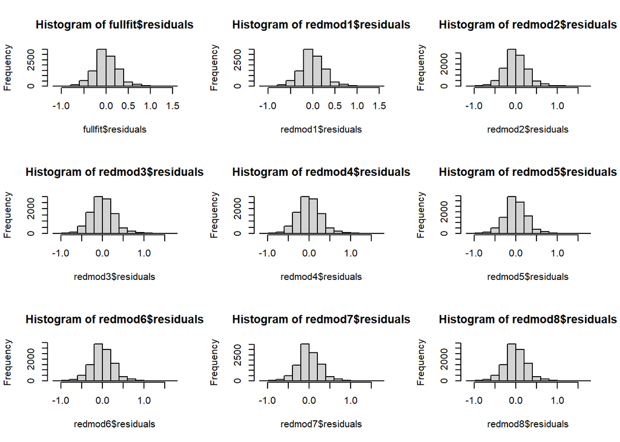

```r
# Create a df of residuals of our linear models

par(mfrow=c(3,3))
hist(fullfit$residuals)
hist(redmod1$residuals)
hist(redmod2$residuals)
hist(redmod3$residuals)
hist(redmod4$residuals)
hist(redmod5$residuals)
hist(redmod6$residuals)
hist(redmod7$residuals)
hist(redmod8$residuals)
```

```r
# QQPlots of residuals of our linear models
par(mfrow=c(3,3))
qqPlot(fullfit$residuals)
```

```
[1] 10048  4283
```

```r
qqPlot(redmod1$residuals)
```

```
[1] 10048  4283
```

```r
qqPlot(redmod2$residuals)
```

```
[1] 1478 2618
```

```r
qqPlot(redmod3$residuals)
```

```
[1] 2618 1478
```

```r
qqPlot(redmod4$residuals)
```

```
[1] 2618 1478
```

```r
qqPlot(redmod5$residuals)
```

```
[1] 10048  4283
```

```r
qqPlot(redmod6$residuals)
```

```
[1] 10048  4283
```

```r
qqPlot(redmod7$residuals)
```

```
[1] 10048  4283
```

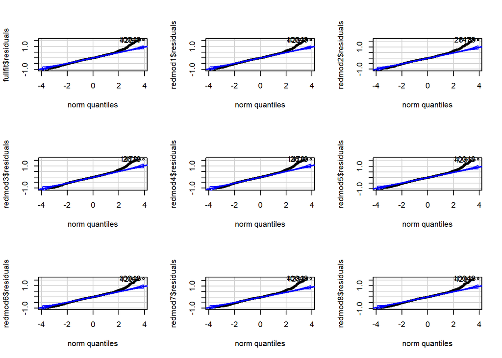

```
[1] 10048  4283
```

```r
qqPlot(redmod8$residuals)
```

No particular model seems to be worse in normality than others. Therefore, we compare our 9 linear models by error rates to determine which one to use as our final linear model. Some of those error rate statistics include $AIC$, $BIC$, and $R^2$ values.

```r
# We can compare our 9 linear models

#calculate AIC of each model

#this will create a dataframe whose rownames are the models, with columns for the df and AIC of each model
result <- AIC(fullfit, redmod1, redmod2, redmod3, redmod4, redmod5, redmod6, redmod7, redmod8)

#add other metrics to your table
#make sure you keep your models in the same order here as they were when you created your results table
models <- list(fullfit, redmod1, redmod2, redmod3, redmod4, redmod5, redmod6, redmod7, redmod8)

#add a column for BIC to the results
result$BIC <- sapply(models, BIC)

model_summary <- lapply(models, summary)

#now we will use a for loop to easily extract the R^2 and adj R^2 value for each model from its summary, and store them in new columns in the results table

for(i in 1:length(models)){ #this creates a variable i that starts with the value i=1
  result$rsq[i] <- model_summary[[i]]$r.squared #we assign the rsq value from model i to the i'th row of the column 'rsq' in the table 'results'
  result$adj_rsq[i] <- model_summary[[i]]$adj.r.squared #same for adjusted rsq
} #now we go back to the beginning of the for-loop, add 1 to the value of i, and do everything again


kable(result, digits = 9, align = "c") #We see that redmod8 has the lowest AIC and BIC values and the highest R^2 so we found our model.
```

|  | df | AIC | BIC | rsq | adj_rsq |
| --- | --- | --- | --- | --- | --- |
| fullfit | 29 | 2521.000 | 2731.999 | 0.7181596 | 0.7174450 |
| redmod1 | 29 | 2521.000 | 2731.999 | 0.7181596 | 0.7174450 |
| redmod2 | 28 | 3250.802 | 3454.526 | 0.6981648 | 0.6974279 |
| redmod3 | 28 | 4179.711 | 4383.435 | 0.6707287 | 0.6699248 |
| redmod4 | 28 | 4179.711 | 4383.435 | 0.6707287 | 0.6699248 |
| redmod5 | 30 | 2287.907 | 2506.182 | 0.7242975 | 0.7235725 |
| redmod6 | 29 | 2306.746 | 2517.746 | 0.7237588 | 0.7230584 |
| redmod7 | 24 | 2725.833 | 2900.453 | 0.7124312 | 0.7118374 |
| redmod8 | 27 | 2282.587 | 2479.035 | 0.7242799 | 0.7236327 |

#### K-Fold Cross-Validation

As a way to double-check our work, we used K-fold cross-validation to verify our R^2 value.

```r
#Split the data let's do 80 20

# setting seed for reproducibility
set.seed(666)
#separate the data into a training set (most of the data) and a test set (a few observations, or <20% of rows)
splitter <- sample(1:nrow(planestransformed), 0.2*nrow(planestransformed), replace = F) #pick 30 random rows from planes to reserve as test data
lm.train <- planestransformed[-splitter,] #leave those rows out of the training data
lm.test <- planestransformed[splitter,] #use them to create a set of test data
lm.test <- cbind(sampleID = rownames(lm.test), lm.test)
rownames(lm.test) <-1:nrow(lm.test)

# Define training control
train.control <- trainControl(method = "cv",
                              number = 10)
# Train the model
model <- train(Price ~Airline + Destination + Weekday  + Holiday + TotalStops + FlightTime + TotalStops*FlightTime, data = lm.train, method = "lm", trControl = train.control)
# Summarize the results
summary(model)$adj.r.squared
```

```
[1] 0.7211768
```

This K-fold cross-validation verified our seemingly scaled $R^2$ value. While the numbers are not exactly the same, resting at $0.7236327$ for our model and $0.7211768$ for our cross-validation, is is a result of our fitted model redmod being fit on all $10,677$ observations in our dataset, while the training model used for k-fold cross-validation is only fit on the $8,541$ observations in its training set.

#### Final Model

```r
anova(redmod8)
```

```
Analysis of Variance Table

Response: Price
                         Df  Sum Sq Mean Sq   F value    Pr(>F)
Airline                  10 1266.69 126.669 1751.6037 < 2.2e-16 ***
Destination               5  512.61 102.522 1417.6951 < 2.2e-16 ***
Weekday                   6   27.14   4.523   62.5491 < 2.2e-16 ***
Holiday                   1    0.51   0.515    7.1149  0.007656 **
TotalStops                1  198.30 198.295 2742.0685 < 2.2e-16 ***
FlightTime                1    0.75   0.753   10.4173  0.001252 **
TotalStops:FlightTime     1   17.31  17.309  239.3492 < 2.2e-16 ***
Residuals             10651  770.24   0.072
---
Signif. codes:  0 '***' 0.001 '**' 0.01 '*' 0.05 '.' 0.1 ' ' 1
```

Let us verify that our sample size used to fit redmod8 was correct. We will do so both computationally and algebraically.

```r
# verifies our n used to fit redmod8
nrow(planestransformed)
```

```
[1] 10677
```

$$SSE = n * MSE$$

$$RMSE = \sqrt{MSE}$$

So we have an SSE of 770.24 and an n of 10677

```r
# calculate RMSE of REDMOD8
sqrt(770.24/10677)
```

```
[1] 0.2685891
```

We arrive at a RMSE of 0.2685891.

This rMSE value is orders of smaller than what we obtain for our other models. We will discuss why in our conclusions.

[figure not shown]

*Overfitting, scaling, or something else?*

#### Visualization

Let’s visualize our final model.

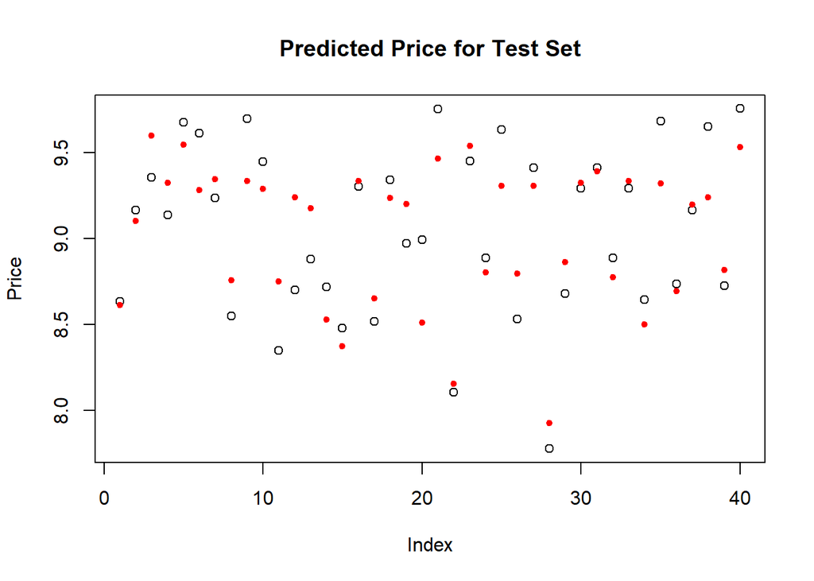

```r
# setting seed for reproducibility
set.seed(123)
#separate the data into a training set (most of the data) and a test set (a few observations, or <10% of rows)
splitter <- sample(1:nrow(planestransformed), 40, replace = F) #pick 40 random rows from planes to reserve as test data
lin_train <- planestransformed[-splitter,] #leave those rows out of the training data
lin_test <- planestransformed[splitter,] #use them to create a set of test data
lin_test <- cbind(sampleID = rownames(lin_test), lin_test)
rownames(lin_test) <-1:nrow(lin_test)

lin2_split <- lm(Price~Airline + Destination + Weekday  + Holiday + TotalStops + FlightTime + TotalStops*FlightTime, data = planestransformed) #fit the final model, redmod8 using JUST the training set as the data argument

prediction <- predict(lin2_split, lin_test) #use the fitted model to predict values for your test data

plot(lin_test$Price, pch=1, xlab = "Index", ylab = "Price", main = "Predicted Price for Test Set") #plot the actual test data values
points(prediction, pch=20, col = "red") #plot the model predictions for those points
```

In the interest of visualizing the accuracy of our linear model, we chose to use a very small test set (40 observations) for our graphs on our fitted linear model redmod8. If we includwd any more observations in our visualization, it would all just look like a big blob. Let us be clear: this limit of 40 observations is only for visualizations, and nothing else!

Through these visualizations, we see that there is high variance in residual error.

### Regression Tree

#### Setup

```r
# set seed for reproducibility
set.seed(123)

# Splitting the data
planes_idx = sample(1:nrow(planestransformed), 0.8*nrow(planestransformed))
planes_trn = planes[planes_idx,]
planes_tst = planes[-planes_idx,]


# fit an unpruned tree to the data
planes_tree = tree(Price ~ ., data = planes_trn)
# summary(planes_tree)
```

This is sufficient to plot an unpruned single regression tree.

#### Tree Plots

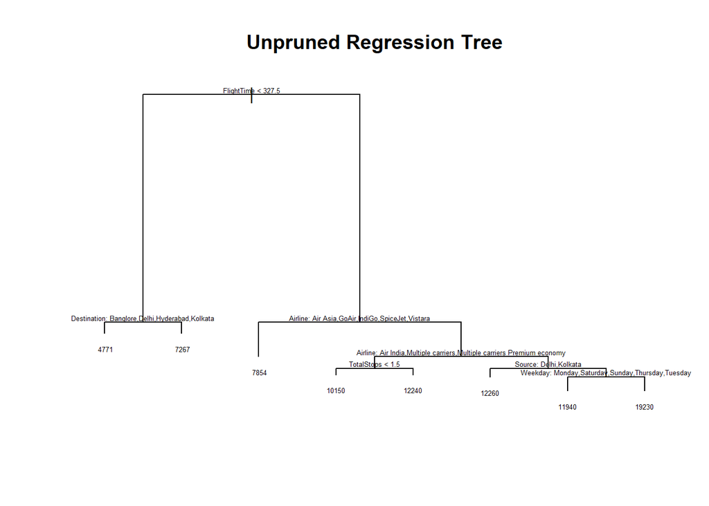

```r
# plotting our unpruned tree
plot(planes_tree)
text(planes_tree, pretty = 0, cex = 0.4, pos = 3, offset = -.4)
title(main = "Unpruned Regression Tree")
```

Cross validation

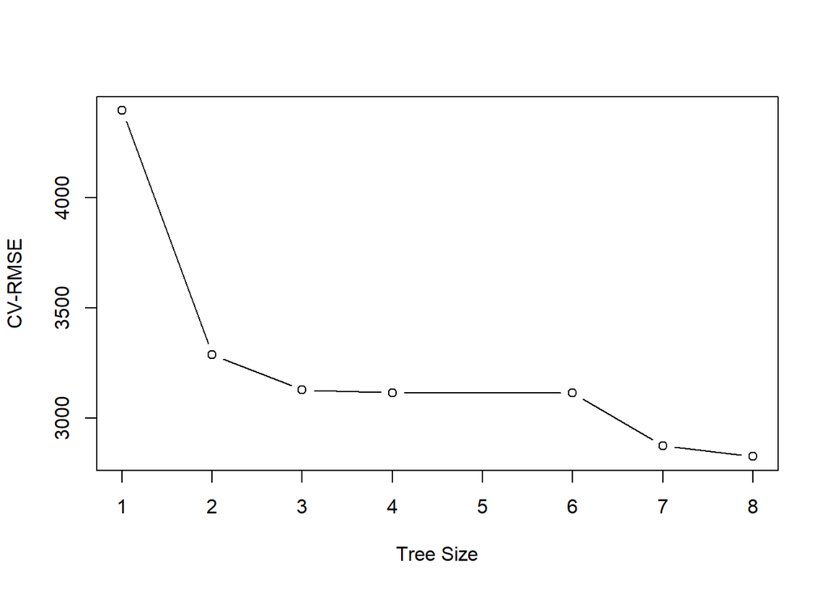

```r
set.seed(123)
planes_tree_cv = cv.tree(planes_tree)
plot(planes_tree_cv$size, sqrt(planes_tree_cv$dev / nrow(planes_trn)), type = "b",
     xlab = "Tree Size", ylab = "CV-RMSE")
```

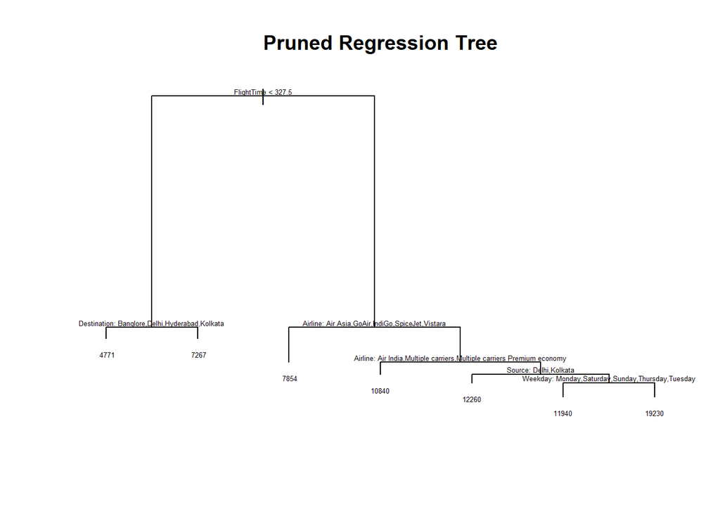

```r
# prune tree
planes_tree_prune = prune.tree(planes_tree, best = 7)

# summary(planes_tree_prune)

# plotting the pruned tree
plot(planes_tree_prune)
text(planes_tree_prune, pretty = 0, cex = .4, pos = 3, offset = -.4)
title(main = "Pruned Regression Tree")
```

And just for fun, let’s check out the extremely simple pruned tree of size 3. This tree may not be very accurate, but it is extremely easy to interpret!

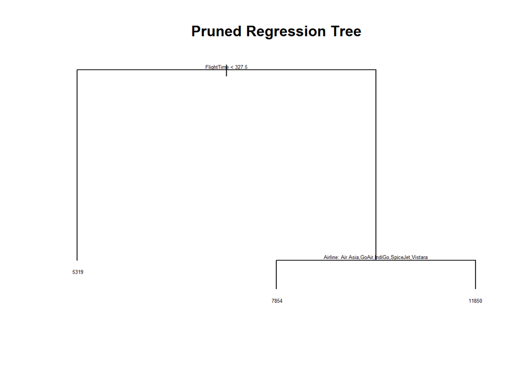

```r
# prune tree
planes_tree_prune_simple = prune.tree(planes_tree, best = 3)


# plotting the simple pruned tree
plot(planes_tree_prune_simple)
text(planes_tree_prune_simple, pretty = 0, cex = .4, pos = 3, offset = -.4)
title(main = "Pruned Regression Tree")
```

#### Error Rates of Tree Plots

Let’s compare our size = $7$ ‘Goldilocks’ regression tree to an additive linear model and use RMSE as our metric.

```r
rmse = function(actual, predicted) {
  sqrt(mean((actual - predicted) ^ 2))
}

# training RMSE two ways
sqrt(summary(planes_tree_prune)$dev / nrow(planes_trn))
```

```
[1] 2853.061
```

```r
planes_prune_trn_pred = predict(planes_tree_prune, newdata = planes_trn)

#rmse(planes_prune_trn_pred, planes_trn$Price)

# same results for both methods; we calculated correctly
```

```r
# test RMSE
planes_prune_tst_pred = predict(planes_tree_prune, newdata = planes_tst)
rmse(planes_prune_tst_pred, planes_tst$Price)
```

```
[1] 3077.688
```

```r
planes_prune_tst_pred_simple = predict(planes_tree_prune_simple, newdata = planes_tst)
rmse(planes_prune_tst_pred_simple, planes_tst$Price)
```

```
[1] 3378.582
```

Our ‘Goldilocks’ pruned tree has a test rMSE of $3077.688$, while our ‘It’s Just That Simple’ pruned tree has a test rMSE of $3378.582$. We shall exclusively use our Goldilocks tree going forward.

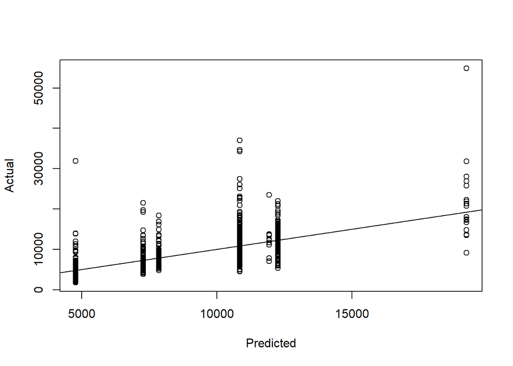

```r
# plotting pred vs actual

plot(planes_prune_tst_pred, planes_tst$Price, xlab = "Predicted", ylab = "Actual")
abline(0, 1)
```

#### Complications with Trujet

```r
planes_lm = lm(Price ~ ., data = planes_trn)
#planes_lm_pred = predict(planes_lm, newdata = planes_tst) # THROWS AN ERROR!!!!
#plot(planes_lm_pred, planes_tst$Price, xlab = "Predicted", ylab = "Actual")
#abline(0, 1)
```

For our decision tree models, we need to drop the Trujet airline. There is only one observation of this airline, so it cannot coexist in both the training and test datasets. This makes it almost impossible to work with, and since it exists in less than 1/10000 of our data points, the simplest solution is to remove it from our dataset.

Note that while removing problematic observations is usually a faux pas in the world of statistical modeling, it makes sense in context. We are trying to build a model to predict Price, and one of our ways of doing so is in our airline brand. An airline brand with only one flight cannot predict anything, and just introduces uncertainty similar to Jet Airways Business.

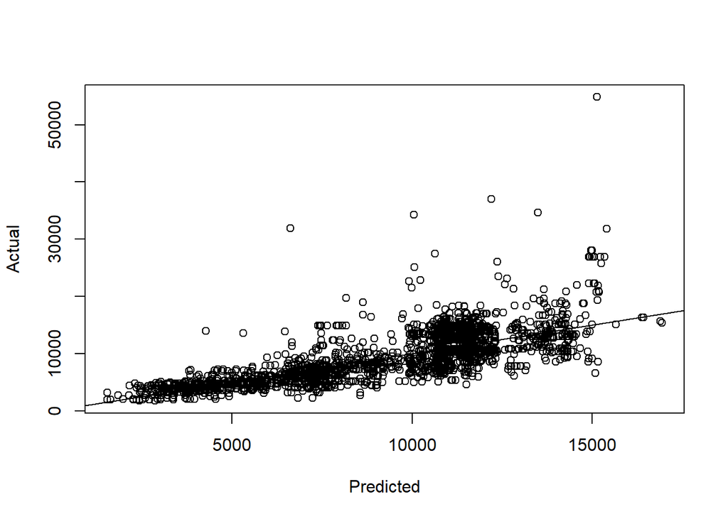

```r
# filter
planes_tst <- planes_tst%>%
  filter(Airline!="Trujet")

# plot
planes_lm = lm(Price ~ ., data = planes_trn)
planes_lm_pred = predict(planes_lm, newdata = planes_tst)
plot(planes_lm_pred, planes_tst$Price, xlab = "Predicted", ylab = "Actual")
abline(0, 1)
```

```r
rmse(planes_lm_pred, planes_tst$Price)
```

```
[1] 3075.063
```

### Random Forest

#### Setup

```r
planes_forest = randomForest(Price ~ ., data = planes_trn, mtry = 4, importance = TRUE, ntrees = 500)
#planes_forest
```

```r
# View importance of each importance variable
importance(planes_forest, type = 1)
```

```
                %IncMSE
Airline      155.897593
Source        30.494470
Destination   42.769905
Weekday       71.708596
Holiday       -4.518405
FlightWindow  43.972256
TotalStops    29.595107
FlightTime    43.900236
```

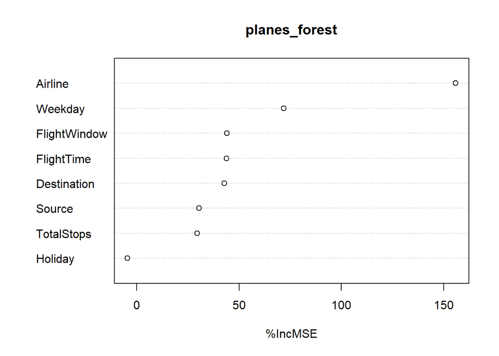

```r
# plotting the importance of each importance variable
varImpPlot(planes_forest, type = 1)
```

These graphs show the importance of each variable to our random sampling. There seems to be the most hinging on Airline, which makes sense given the different pricing plans of different airline brands.

#### Error Plot

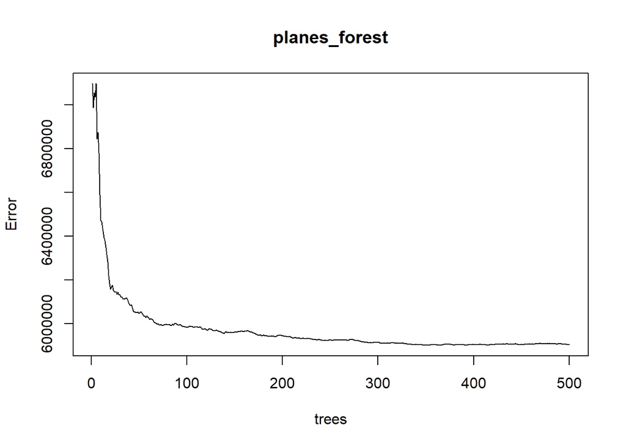

```r
#Plot error

plot(planes_forest)
```

We see that our usage of 500 trees is sufficient for minimizing error rate without crashing our computers.

[figure not shown]

*Daisy May the cat, stats genius*

#### Plot Test Data

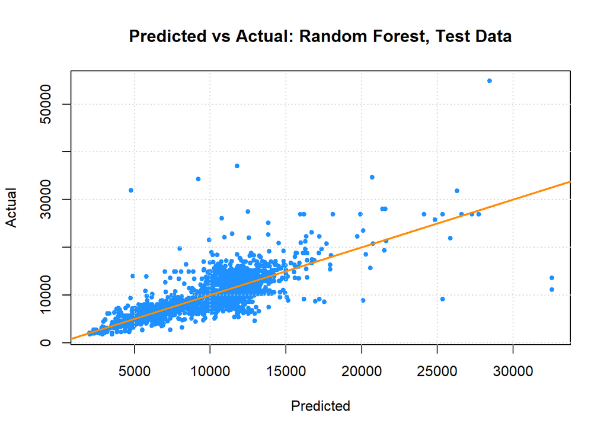

```r
# Now I'm plotting this forest
planes_forest_tst_pred = predict(planes_forest, newdata = planes_tst)
plot(planes_forest_tst_pred, planes_tst$Price,
     xlab = "Predicted", ylab = "Actual",
     main = "Predicted vs Actual: Random Forest, Test Data",
     col = "dodgerblue", pch = 20)
grid()
abline(0, 1, col = "darkorange", lwd = 2)
```

```r
# Calculating the RMSE
forest_tst_rmse = rmse(planes_forest_tst_pred, planes_tst$Price)
forest_tst_rmse
```

```
[1] 2690.16
```

```r
planes_forest_trn_pred = predict(planes_forest, newdata = planes_trn)
forest_trn_rmse = rmse(planes_forest_trn_pred, planes_trn$Price)
forest_oob_rmse = rmse(planes_forest$predicted, planes_trn$Price)

forest_trn_rmse
```

```
[1] 1855.291
```

```r
forest_oob_rmse
```

```
[1] 2429.713
```

### Here’s also how to draw a table in markdown.

| Data | RMSE |
| --- | --- |
| Test | 2690.16 |
| Train | 1855.291 |
| OOB | 2429.713 |

We calculate our test rMSE as $2690.16$, our training rMSE as $1855.291$, and our out-of-bag rMSE as $2429.713$.

We believe the random forest and the linear model fitted might be rather similar to each other in RMSE.

## Conclusions

### Comparison of rMSE values

[output not shown]

[output not shown]

Wait a second…

[figure not shown]

*What’s up with the linear rMSE?*

Our linear model’s rMSE is far, far lower than every other result. We suspect that this rMSE value is scaled or normalized in some way that the rest of our models’ error rates are not. This is likely a mistake in our coding, due to a regressive models being outside the scope of the project this report was created for. Please have pity on us, for we are but lowly undergraduate students!

### Quantitative Results

Due to the possibility of scaling, we believe that our Random Forest model is the most accurate for predicting the price of a future airplane route based on its other information.

While Random Forest may be the most accurate, ‘It’s Just That Simple’ deserves a shout-out for being the simplest to understand. It’s just two questions! “Is your flight short? Well, then it’s gonna be cheap. No? Well, is it on a budget airline brand? If yes, it’ll cost you a medium amount. If not, better pony up the dough, cowboy!”

### Previous Reports

As our dataset was on Kaggle, we were able to see a few people had worked on the same data set we had. Every single one of them relied on a random forest method as their primary modeling tool, and every single one picked Python as their language of choice rather than R, as we did.

### Final Word

When my parents said something that I didn’t like to hear, like ‘Eat your vegetables’ or ‘You can’t vote yet, you’re a literal child’, my first line of defense was usually to ask them why that is. I assume that is what I did in the airport, on our way to visit our relatives. And I imagine their response to me was what it usually was when they didn’t have energy to deal with my antics: “Ryan, it’s complicated.”

Well, Mom and Dad, you were right. It is complicated. Complex-sounding questions, like “Is price positively correlated with total number of stops for the average flight in India from March to June 2019 logged by Shray Garg on Kaggle”, have simple answers, like “Yes they are!” But simple-sounding questions, like “Do we have to take connecting flights to save money?”, have complex answers.

As a child, I thought the world was easy to understand. Only now, as an adult, do I begin to understand just how much I was asking to know as a child, and how little we have just begun to understand.

…

Those darn kids and their naive curiosities! Personally, I blame the Googles!

## Credits

This project was created by Gia Ahn and Ryan Scibetta. Ms. Ahn wrote most of the code and models, while Mr. Scibetta wrote most of the narration and analysis. The project managing and conceptual work was done collaboratively.

Additional help was provided by Professor Kathleen Coburn, under whose supervision this project was created, and the anonymous benefactor who wrote UCSB PSTAT 131’s lab exercises. Their work is paraphrased throughout the lasso and ridge regressions.

Online resources used:

- For Ridge, Lasso, and OLS: https://rstudio-pubs-static.s3.amazonaws.com/257535_4218def5fb0945a7a5c09126f385aa59.html#purpose-of-the-case-study
- For Regression Trees: https://daviddalpiaz.github.io/r4sl/trees.html#regression-trees]
- For Random Forest Sampling: https://daviddalpiaz.github.io/r4sl/ensemble-methods.html

Image credits go to Matt Groening for the Fry meme, and Studio C for the Batman meme.

Special thanks to Roman, Zeus, Loki, and Daisy May, four wonderful pets.

Thank you for reading!